# DHA Service Access and Coverage Indicators

# 1 Aim

Birth and death registration may be incomplete due to the inaccesibility of home affairs offices registration occurs. A potential barrier to registration may be the distnace neede to travel. We aim to determine the proportion of the population within reasonable distances of home affairs offices.

# 2 Methodology

The coordinates of home affairs offices were taken from Tom Moultrie’s .dta file. This appears to omit offices in hospitals.

To determine the number of people within a certain distance of a home affairs office we explored options before finalising with the third.

1. We measured the distance between the nearest paris of offices. We took the median half distance as the distance each person in the population would need to travel to their nearest offices. The median half distance between each office within each district was assumed to apply to all populations in the district, this however assumes that should two HA offices be far apart, then all population is out of reach of the office, this underesitmated the coverage, especially in rural areas.
2. We then created a 1km grid pattiern. We assumeed uniform distribution of population within each district based on that districts population and distributed to these grid points. This, while not knocking out rural areas completely, ignores the fact that populations are likely to be clustered.
3. The third method assumes that population is clustered around DHA offices, uniformly across rural and urban areas (same distribution around all offices, in proportion ot the districts population). Other than a visual inspection of the map, I don’t have data to verify the decay of population density around HA offices. In addition, the main with this assumption is that it assumes that all population nodes are situated around DHA offices, which is unlikely to be true in rural areas.

The second and third methods utilise population density models. Three models are available for distributing population across grid points:

**1. Uniform Distribution (method 2)**
$$w_i = 1$$

**2. Inverse Power Model (method 3)**
$$w_i = \frac{1}{(d_i + 1)^{\alpha}}$$

where $d_i$ is the distance (km) from grid point $i$ to the nearest office, and $\alpha$ is the decay parameter (default 1.5). The +1 offset prevents division by zero.

**3. Exponential Decay Model (not used)**
$$w_i = e^{-\alpha \cdot d_i}$$

### 2.0.1 Population Allocation

Weights are normalised within each district to preserve total district population:

$$\hat{w}_i = \frac{w_i}{\sum_{j \in d} w_j}$$

The population at each grid point is then:

$$P_i = P_d \cdot \hat{w}_i$$

where $P_d$ is the total population of district $d$.

### 2.0.2 Distance-to-Access Metrics

Grid points were plotted in a 1km grid pattern. We summed the population value of each grid within the specified distance bands (10km and 20km) to get the proportion of the district population within each distance band.

### 2.0.3 Limitations

- Population is modelled, not observed at sub-district or enumeration area level
- Distance are straigh-line, not road-network or travel-time
- Office capacity and service quality are not accounted for
- Satellite offices are not recorded in the dataset.

Without trying to assume too much more, I would suggest we request enumeration area census data (even if it is old and imperfect) to get an idea of how population is distributed around DHA offices and also to identify population clusters without offices.

# 3 National overview maps

## 3.1 Population distribution (district total)

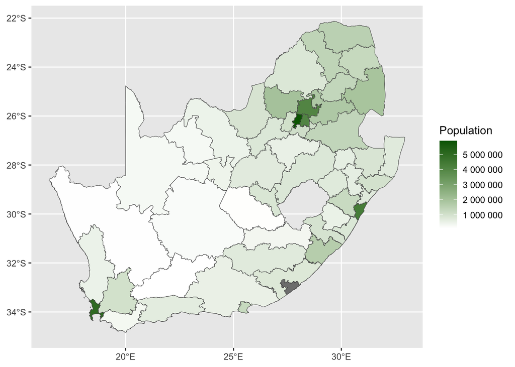

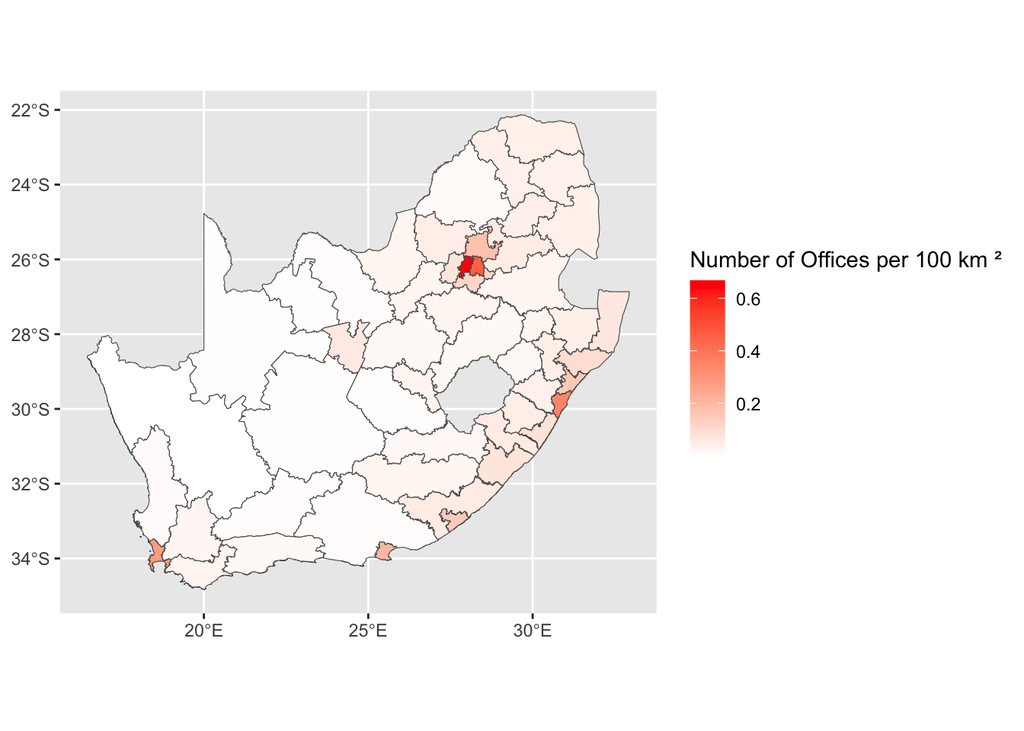

## 3.3 Modelled population distribution around offices

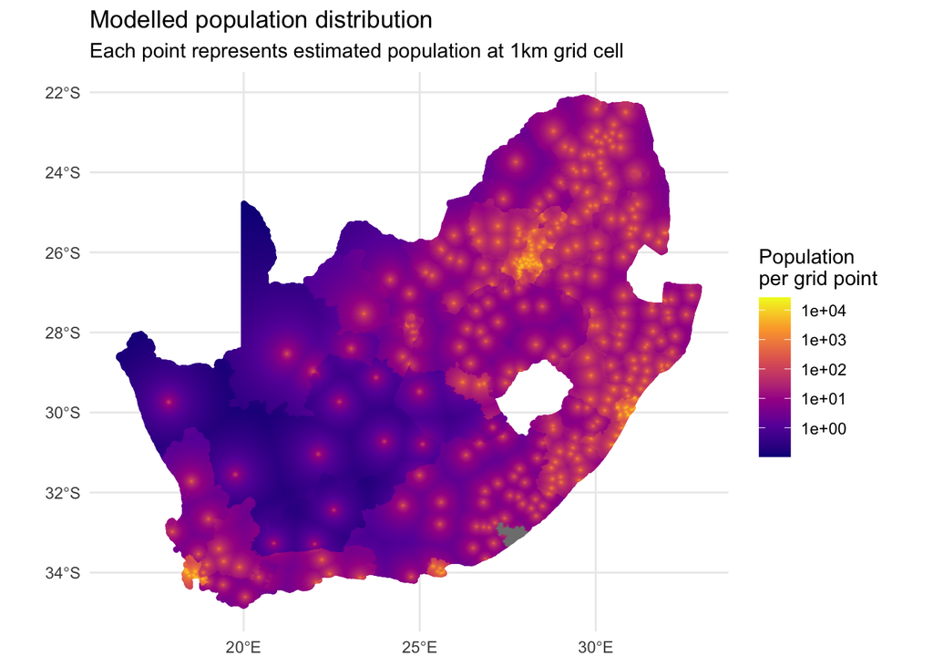

Table 1

| District | Total Population | Population within 10 km | % Population within 10 km | Population within 20 km | % Population within 20 km | Median Distance to Nearest DHA Office (km) |
| --- | --- | --- | --- | --- | --- | --- |
| Alfred Nzo | 935,303 | 455,654 | 49 | 743,056 | 79 | 10 |
| Amajuba | 610,841 | 248,305 | 41 | 412,243 | 67 | 7 |
| Amathole | 792,612 | 384,504 | 49 | 624,102 | 79 | 14 |
| Bojanala Platinum | 1,985,081 | 973,231 | 49 | 1,498,577 | 75 | 7 |
| Buffalo City | 0 | 0 |  | 0 |  | 7 |
| Cape Winelands | 1,014,432 | 393,345 | 39 | 660,490 | 65 | 22 |
| Capricorn | 1,412,657 | 704,095 | 50 | 1,090,472 | 77 | 7 |
| Central Karoo | 77,157 | 19,338 | 25 | 33,406 | 43 | 61 |
| Chris Hani | 717,289 | 284,460 | 40 | 477,557 | 67 | 19 |
| City of Cape Town | 5,030,497 | 4,099,372 | 81 | 4,680,809 | 93 | 6 |
| City of Johannesburg | 5,900,321 | 5,628,983 | 95 | 5,892,801 | 100 | 5 |
| City of Tshwane | 4,038,061 | 2,807,261 | 70 | 3,797,729 | 94 | 6 |
| Dr Kenneth Kaunda | 807,057 | 306,766 | 38 | 534,494 | 66 | 26 |
| Dr Ruth Segomotsi Mompati | 474,901 | 126,707 | 27 | 226,657 | 48 | 37 |
| Ehlanzeni | 1,928,692 | 949,462 | 49 | 1,514,775 | 79 | 15 |
| Ekurhuleni | 4,059,057 | 3,606,629 | 89 | 4,026,309 | 99 | 4 |
| Fezile Dabi | 536,755 | 210,022 | 39 | 354,982 | 66 | 26 |
| Frances Baard | 438,829 | 252,122 | 57 | 344,875 | 79 | 7 |
| Garden Route | 673,192 | 231,969 | 34 | 359,567 | 53 | 26 |
| Gert Sibande | 1,367,513 | 499,243 | 37 | 865,389 | 63 | 24 |
| Harry Gwala | 507,708 | 244,652 | 48 | 393,555 | 78 | 15 |
| Joe Gqabi | 354,931 | 120,698 | 34 | 201,178 | 57 | 26 |
| John Taolo Gaetsewe | 296,434 | 60,904 | 21 | 105,422 | 36 | 59 |
| King Cetshwayo | 992,551 | 584,675 | 59 | 878,508 | 89 | 11 |
| Lejweleputswa | 698,356 | 237,433 | 34 | 415,209 | 59 | 22 |
| Mangaung | 857,973 | 368,652 | 43 | 569,402 | 66 | 7 |
| Mopani | 1,266,834 | 637,249 | 50 | 965,505 | 76 | 11 |
| Namakwa | 129,515 | 18,623 | 14 | 32,228 | 25 | 102 |
| Nelson Mandela Bay | 1,263,632 | 913,990 | 72 | 1,177,353 | 93 | 6 |
| Ngaka Modiri Molema | 916,907 | 356,377 | 39 | 585,529 | 64 | 11 |
| Nkangala | 1,779,928 | 915,035 | 51 | 1,379,990 | 78 | 15 |
| O.R. Tambo | 1,623,984 | 901,159 | 55 | 1,383,467 | 85 | 11 |
| Overberg | 329,835 | 129,159 | 39 | 214,445 | 65 | 30 |
| Pixley ka Seme | 219,155 | 44,535 | 20 | 78,796 | 36 | 61 |
| Sarah Baartman | 527,418 | 137,390 | 26 | 236,924 | 45 | 36 |
| Sedibeng | 1,061,185 | 698,345 | 66 | 956,982 | 90 | 5 |
| Sekhukhune | 1,333,432 | 623,524 | 47 | 1,030,150 | 77 | 14 |
| Thabo Mofutsanyana | 810,097 | 281,906 | 35 | 474,807 | 59 | 21 |
| Ugu | 831,709 | 410,976 | 49 | 648,175 | 78 | 16 |
| Umzinyathi | 607,975 | 279,573 | 46 | 481,574 | 79 | 20 |
| Vhembe | 1,527,097 | 814,784 | 53 | 1,210,958 | 79 | 11 |
| Waterberg | 826,172 | 270,753 | 33 | 469,023 | 57 | 20 |
| West Coast | 502,576 | 158,658 | 32 | 266,241 | 53 | 54 |
| West Rand | 1,046,310 | 595,362 | 57 | 881,713 | 84 | 7 |
| Xhariep | 136,652 | 32,346 | 24 | 58,520 | 43 | 33 |
| ZF Mgcawu | 295,250 | 65,365 | 22 | 109,046 | 37 | 50 |
| Zululand | 901,275 | 416,978 | 46 | 696,859 | 77 | 14 |
| eThekwini | 4,374,202 | 3,566,221 | 82 | 4,314,339 | 99 | 4 |
| iLembe | 742,038 | 487,512 | 66 | 715,374 | 96 | 14 |
| uMgungundlovu | 1,220,477 | 558,333 | 46 | 974,950 | 80 | 18 |
| uMkhanyakude | 711,366 | 369,938 | 52 | 571,470 | 80 | 20 |
| uThukela | 732,104 | 233,311 | 32 | 401,014 | 55 | 29 |
| Total | 62,225,326 | 37,715,880 | 61 | 51,016,996 | 82 | 14 |

## 3.4 Interactive map of DHA offices and population coverage

[interactive chart not shown]